# P6_analyse_byvarié_Détectez_des_faux_billets

```python
# import des librairies dont nous aurons besoin
import pandas as pd
import numpy as np
import matplotlib.pyplot as plt
import seaborn as sns
import re
import datetime as dt
import scipy.stats as st
```

```python
# chargement et affichage des données


billets= pd.read_csv('D:\\Aopenclassroom\\P6\\p6_données/notes.csv')
test= pd.read_csv('D:\\Aopenclassroom\\P6\\p6_données/Test.csv')
```

```python
billets
```

|  | is_genuine | diagonal | height_left | height_right | margin_low | margin_up | length |
| --- | --- | --- | --- | --- | --- | --- | --- |
| 0 | True | 171.81 | 104.86 | 104.95 | 4.52 | 2.89 | 112.83 |
| 1 | True | 171.67 | 103.74 | 103.70 | 4.01 | 2.87 | 113.29 |
| 2 | True | 171.83 | 103.76 | 103.76 | 4.40 | 2.88 | 113.84 |
| 3 | True | 171.80 | 103.78 | 103.65 | 3.73 | 3.12 | 113.63 |
| 4 | True | 172.05 | 103.70 | 103.75 | 5.04 | 2.27 | 113.55 |
| ... | ... | ... | ... | ... | ... | ... | ... |
| 165 | False | 172.11 | 104.23 | 104.45 | 5.24 | 3.58 | 111.78 |
| 166 | False | 173.01 | 104.59 | 104.31 | 5.04 | 3.05 | 110.91 |
| 167 | False | 172.47 | 104.27 | 104.10 | 4.88 | 3.33 | 110.68 |
| 168 | False | 171.82 | 103.97 | 103.88 | 4.73 | 3.55 | 111.87 |
| 169 | False | 171.96 | 104.00 | 103.95 | 5.63 | 3.26 | 110.96 |

170 rows × 7 columns

```python
billets.describe()
```

|  | diagonal | height_left | height_right | margin_low | margin_up | length |
| --- | --- | --- | --- | --- | --- | --- |
| count | 170.000000 | 170.000000 | 170.000000 | 170.000000 | 170.000000 | 170.000000 |
| mean | 171.940588 | 104.066353 | 103.928118 | 4.612118 | 3.170412 | 112.570412 |
| std | 0.305768 | 0.298185 | 0.330980 | 0.702103 | 0.236361 | 0.924448 |
| min | 171.040000 | 103.230000 | 103.140000 | 3.540000 | 2.270000 | 109.970000 |
| 25% | 171.730000 | 103.842500 | 103.690000 | 4.050000 | 3.012500 | 111.855000 |
| 50% | 171.945000 | 104.055000 | 103.950000 | 4.450000 | 3.170000 | 112.845000 |
| 75% | 172.137500 | 104.287500 | 104.170000 | 5.127500 | 3.330000 | 113.287500 |
| max | 173.010000 | 104.860000 | 104.950000 | 6.280000 | 3.680000 | 113.980000 |

perplot pour toutes les variables pairplot (nuage de point)lignes et colonnes

```python
billets.shape
```

```
(170, 7)
```

colonnes

```python
billets.columns
```

```
Index(['is_genuine', 'diagonal', 'height_left', 'height_right', 'margin_low',
       'margin_up', 'length'],
      dtype='object')
```

les informations

```python
billets.info
```

[output not shown]

```python
billets.value_counts()
```

```
is_genuine  diagonal  height_left  height_right  margin_low  margin_up  length
False       171.38    103.78       103.70        5.22        3.43       111.60    1
True        171.97    103.69       104.17        4.32        3.00       112.82    1
            171.88    103.66       103.52        4.66        2.75       113.25    1
            171.91    104.28       103.92        3.64        3.36       113.15    1
                      104.34       103.77        4.45        2.95       112.66    1
                                                                                 ..
False       172.10    104.30       104.21        4.07        3.41       111.27    1
            172.11    104.23       104.45        5.24        3.58       111.78    1
            172.22    104.17       104.07        4.52        3.67       112.13    1
                      104.41       104.64        5.20        3.37       112.20    1
True        172.75    104.33       103.97        4.34        3.14       113.12    1
Length: 170, dtype: int64
```

```python
billets.sort_values('diagonal', ascending = False).head()
```

|  | is_genuine | diagonal | height_left | height_right | margin_low | margin_up | length |
| --- | --- | --- | --- | --- | --- | --- | --- |
| 166 | False | 173.01 | 104.59 | 104.31 | 5.04 | 3.05 | 110.91 |
| 34 | True | 172.75 | 104.33 | 103.97 | 4.34 | 3.14 | 113.12 |
| 23 | True | 172.59 | 104.22 | 104.01 | 4.47 | 2.95 | 113.19 |
| 5 | True | 172.57 | 104.65 | 104.44 | 4.54 | 2.99 | 113.16 |
| 56 | True | 172.53 | 103.99 | 103.55 | 4.50 | 3.10 | 113.03 |

```python
billets.sort_values('height_left', ascending = False).head()
```

|  | is_genuine | diagonal | height_left | height_right | margin_low | margin_up | length |
| --- | --- | --- | --- | --- | --- | --- | --- |
| 0 | True | 171.81 | 104.86 | 104.95 | 4.52 | 2.89 | 112.83 |
| 122 | False | 172.29 | 104.72 | 104.86 | 5.71 | 3.16 | 112.15 |
| 5 | True | 172.57 | 104.65 | 104.44 | 4.54 | 2.99 | 113.16 |
| 12 | True | 172.19 | 104.61 | 103.69 | 4.00 | 3.26 | 112.91 |
| 112 | False | 172.32 | 104.60 | 104.83 | 4.84 | 3.51 | 112.55 |

```python
billets.sort_values('height_right', ascending = False).head()
```

|  | is_genuine | diagonal | height_left | height_right | margin_low | margin_up | length |
| --- | --- | --- | --- | --- | --- | --- | --- |
| 0 | True | 171.81 | 104.86 | 104.95 | 4.52 | 2.89 | 112.83 |
| 122 | False | 172.29 | 104.72 | 104.86 | 5.71 | 3.16 | 112.15 |
| 112 | False | 172.32 | 104.60 | 104.83 | 4.84 | 3.51 | 112.55 |
| 109 | False | 172.22 | 104.41 | 104.64 | 5.20 | 3.37 | 112.20 |
| 158 | False | 171.84 | 104.32 | 104.50 | 6.28 | 3.00 | 111.06 |

```python
billets.sort_values('margin_low', ascending = False).head()
```

|  | is_genuine | diagonal | height_left | height_right | margin_low | margin_up | length |
| --- | --- | --- | --- | --- | --- | --- | --- |
| 158 | False | 171.84 | 104.32 | 104.50 | 6.28 | 3.00 | 111.06 |
| 121 | False | 172.07 | 104.50 | 104.23 | 6.19 | 3.07 | 111.21 |
| 153 | False | 171.61 | 104.04 | 104.06 | 6.19 | 3.08 | 110.73 |
| 131 | False | 171.56 | 104.17 | 103.87 | 6.16 | 3.38 | 111.55 |
| 135 | False | 171.86 | 104.12 | 104.10 | 6.01 | 3.34 | 111.91 |

```python
billets.sort_values('margin_up', ascending = False).head()
```

|  | is_genuine | diagonal | height_left | height_right | margin_low | margin_up | length |
| --- | --- | --- | --- | --- | --- | --- | --- |
| 120 | False | 171.84 | 104.23 | 104.31 | 5.10 | 3.68 | 111.72 |
| 106 | False | 172.22 | 104.17 | 104.07 | 4.52 | 3.67 | 112.13 |
| 129 | False | 171.62 | 104.14 | 104.45 | 4.94 | 3.66 | 111.93 |
| 149 | False | 171.91 | 103.91 | 103.98 | 4.78 | 3.65 | 111.41 |
| 160 | False | 172.50 | 104.07 | 103.71 | 3.82 | 3.63 | 110.74 |

```python
billets.sort_values('length', ascending = False).head()
```

|  | is_genuine | diagonal | height_left | height_right | margin_low | margin_up | length |
| --- | --- | --- | --- | --- | --- | --- | --- |
| 26 | True | 172.41 | 104.14 | 104.06 | 4.45 | 2.94 | 113.98 |
| 25 | True | 172.21 | 104.28 | 104.37 | 4.06 | 3.30 | 113.92 |
| 40 | True | 171.51 | 103.85 | 103.36 | 4.49 | 2.80 | 113.87 |
| 2 | True | 171.83 | 103.76 | 103.76 | 4.40 | 2.88 | 113.84 |
| 11 | True | 172.07 | 103.64 | 103.67 | 3.86 | 3.20 | 113.83 |

```python
billets.dtypes
```

```
is_genuine         bool
diagonal        float64
height_left     float64
height_right    float64
margin_low      float64
margin_up       float64
length          float64
dtype: object
```

entete

```python
billets.head(5).T
```

|  | 0 | 1 | 2 | 3 | 4 |
| --- | --- | --- | --- | --- | --- |
| is_genuine | True | True | True | True | True |
| diagonal | 171.81 | 171.67 | 171.83 | 171.8 | 172.05 |
| height_left | 104.86 | 103.74 | 103.76 | 103.78 | 103.7 |
| height_right | 104.95 | 103.7 | 103.76 | 103.65 | 103.75 |
| margin_low | 4.52 | 4.01 | 4.4 | 3.73 | 5.04 |
| margin_up | 2.89 | 2.87 | 2.88 | 3.12 | 2.27 |
| length | 112.83 | 113.29 | 113.84 | 113.63 | 113.55 |

```python
billets.tail(10).T
```

|  | 160 | 161 | 162 | 163 | 164 | 165 | 166 | 167 | 168 | 169 |
| --- | --- | --- | --- | --- | --- | --- | --- | --- | --- | --- |
| is_genuine | False | False | False | False | False | False | False | False | False | False |
| diagonal | 172.5 | 171.92 | 171.67 | 171.78 | 171.43 | 172.11 | 173.01 | 172.47 | 171.82 | 171.96 |
| height_left | 104.07 | 104.37 | 104.12 | 104.07 | 104.26 | 104.23 | 104.59 | 104.27 | 103.97 | 104.0 |
| height_right | 103.71 | 104.05 | 103.98 | 104.16 | 103.97 | 104.45 | 104.31 | 104.1 | 103.88 | 103.95 |
| margin_low | 3.82 | 4.95 | 5.68 | 5.77 | 5.73 | 5.24 | 5.04 | 4.88 | 4.73 | 5.63 |
| margin_up | 3.63 | 3.04 | 3.18 | 3.3 | 3.14 | 3.58 | 3.05 | 3.33 | 3.55 | 3.26 |
| length | 110.74 | 110.61 | 111.55 | 111.27 | 111.82 | 111.78 | 110.91 | 110.68 | 111.87 | 110.96 |

RECHERCHE DES VALEURS MANQUANTES

```python
billets.isna().sum()
```

```
is_genuine      0
diagonal        0
height_left     0
height_right    0
margin_low      0
margin_up       0
length          0
dtype: int64
```

```python
billets.describe().T
```

|  | count | mean | std | min | 25% | 50% | 75% | max |
| --- | --- | --- | --- | --- | --- | --- | --- | --- |
| diagonal | 170.0 | 171.940588 | 0.305768 | 171.04 | 171.7300 | 171.945 | 172.1375 | 173.01 |
| height_left | 170.0 | 104.066353 | 0.298185 | 103.23 | 103.8425 | 104.055 | 104.2875 | 104.86 |
| height_right | 170.0 | 103.928118 | 0.330980 | 103.14 | 103.6900 | 103.950 | 104.1700 | 104.95 |
| margin_low | 170.0 | 4.612118 | 0.702103 | 3.54 | 4.0500 | 4.450 | 5.1275 | 6.28 |
| margin_up | 170.0 | 3.170412 | 0.236361 | 2.27 | 3.0125 | 3.170 | 3.3300 | 3.68 |
| length | 170.0 | 112.570412 | 0.924448 | 109.97 | 111.8550 | 112.845 | 113.2875 | 113.98 |

les données semblent logiques

```python
billets.isnull().sum()
```

```
is_genuine      0
diagonal        0
height_left     0
height_right    0
margin_low      0
margin_up       0
length          0
dtype: int64
```

```python
billets.isnull().sum()
```

```
is_genuine      0
diagonal        0
height_left     0
height_right    0
margin_low      0
margin_up       0
length          0
dtype: int64
```

```python
billets.head()
```

|  | is_genuine | diagonal | height_left | height_right | margin_low | margin_up | length |
| --- | --- | --- | --- | --- | --- | --- | --- |
| 0 | True | 171.81 | 104.86 | 104.95 | 4.52 | 2.89 | 112.83 |
| 1 | True | 171.67 | 103.74 | 103.70 | 4.01 | 2.87 | 113.29 |
| 2 | True | 171.83 | 103.76 | 103.76 | 4.40 | 2.88 | 113.84 |
| 3 | True | 171.80 | 103.78 | 103.65 | 3.73 | 3.12 | 113.63 |
| 4 | True | 172.05 | 103.70 | 103.75 | 5.04 | 2.27 | 113.55 |

# analyse univarié

## is_genuine

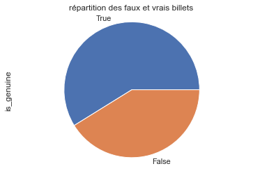

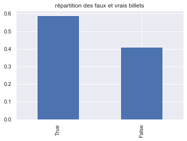

```python
# Diagramme en secteurs
billets["is_genuine"].value_counts(normalize=True).plot(kind='pie')
# Cette ligne assure que le pie chart est un cercle plutôt qu'une éllipse
plt.axis('equal')
plt.title('répartition des faux et vrais billets')
plt.savefig("p6_figures/rep_faux_billets.png")
plt.show() # Affiche le graphique

# Diagramme en tuyaux d'orgues
billets["is_genuine"].value_counts(normalize=True).plot(kind='bar')
plt.title('répartition des faux et vrais billets')
plt.savefig("p6_figures/répartition des faux et vrais billets.png")
plt.show()
```

# analyse byvarié

## diagonal

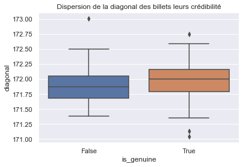

```python
sns.boxplot(x = 'is_genuine', y = 'diagonal', data = billets, palette="deep")
plt.title('Dispersion de la diagonal des billets leurs crédibilité')

plt.savefig("p6_figures/Dispersion de la diagonal des billets leurs crédibilité.png")
plt.show()
```

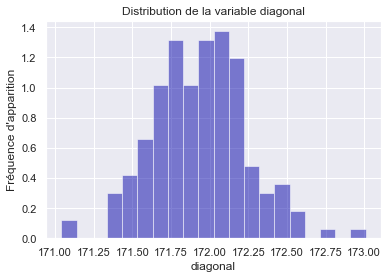

```python
#Visualisation (Histogramme)de la distribution des prix produits
billets['diagonal'].hist(color='#0504aa', alpha=0.5, density=True, bins=20)

plt.title('Distribution de la variable diagonal')
plt.xlabel('diagonal')
plt.ylabel('Fréquence d\'apparition')

plt.savefig("p6_figures/Distribution de la variable diagonal.png")
plt.show()
```

## height_left

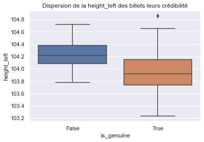

```python
sns.boxplot(x = 'is_genuine', y = 'height_left', data = billets, palette="deep")
plt.title('Dispersion de la height_left des billets leurs crédibilité')

plt.savefig("p6_figures/Dispersion de la height_left des billets leurs crédibilité.png")
plt.show()
```

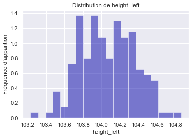

```python
#Visualisation (Histogramme)de la distribution des prix produits
billets['height_left'].hist(color='#0504aa', alpha=0.5, density=True, bins=20)

plt.title('Distribution de height_left')
plt.xlabel('height_left')
plt.ylabel('Fréquence d\'apparition')

plt.savefig("p6_figures/Distribution de height_left.png")
plt.show()
```

## height_right

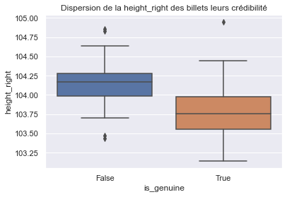

```python
sns.boxplot(x = 'is_genuine', y = 'height_right', data = billets, palette="deep")
plt.title('Dispersion de la height_right des billets leurs crédibilité')

plt.savefig("p6_figures/Dispersion de la height_right des billets leurs crédibilité.png")
plt.show()
```

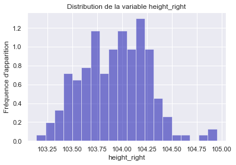

```python
#Visualisation (Histogramme)de la distribution des prix produits
billets['height_right'].hist(color='#0504aa', alpha=0.5, density=True, bins=20)

plt.title('Distribution de la variable height_right')
plt.xlabel('height_right')
plt.ylabel('Fréquence d\'apparition')

plt.savefig("p6_figures/distribution_height_right.png")
plt.show()
```

## margin_low

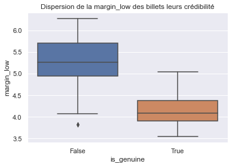

```python
sns.boxplot(x = 'is_genuine', y = 'margin_low', data = billets, palette="deep")
plt.title('Dispersion de la margin_low des billets leurs crédibilité')

plt.savefig("p6_figures/Dispersion de la margin_low des billets leurs crédibilité.png")
plt.show()
```

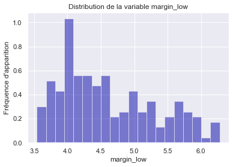

```python
#Visualisation (Histogramme)de la distribution des prix produits
billets['margin_low'].hist(color='#0504aa', alpha=0.5, density=True, bins=20)

plt.title('Distribution de la variable margin_low')
plt.xlabel('margin_low')
plt.ylabel('Fréquence d\'apparition')

plt.savefig("p6_figures/Distribution de la variable margin_low.png")
plt.show()
```

## margin_up

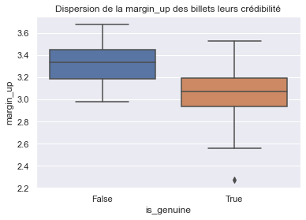

```python
sns.boxplot(x = 'is_genuine', y = 'margin_up', data = billets, palette="deep")
plt.title('Dispersion de la margin_up des billets leurs crédibilité')

plt.savefig("p6_figures/Dispersion de la margin_up des billets leurs crédibilité.png")
plt.show()
```

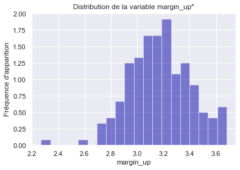

```python
#Visualisation (Histogramme)de la distribution des prix produits
billets['margin_up'].hist(color='#0504aa', alpha=0.5, density=True, bins=20)

plt.title('Distribution de la variable margin_up"')
plt.xlabel('margin_up')
plt.ylabel('Fréquence d\'apparition')

plt.savefig("p6_figures/distribution_margin_up.png")
plt.show()
```

## lengueure des billets

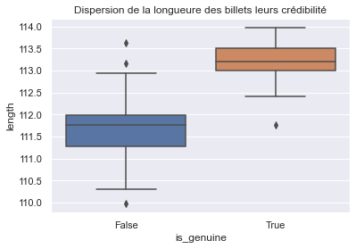

```python
sns.boxplot(x = 'is_genuine', y = 'length', data = billets, palette="deep")
plt.title('Dispersion de la longueure des billets leurs crédibilité')

plt.savefig("p6_figures/longueures_catégorie.png")
plt.show()
```

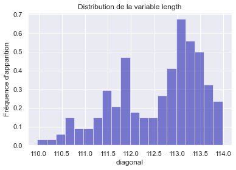

```python
#Visualisation (Histogramme)de la distribution des prix produits
billets['length'].hist(color='#0504aa', alpha=0.5, density=True, bins=20)

plt.title('Distribution de la variable length')
plt.xlabel('diagonal')
plt.ylabel('Fréquence d\'apparition')

plt.savefig("p6_figures/distribution_length.png")
plt.show()
```

```python
billets.head(1)
```

|  | is_genuine | diagonal | height_left | height_right | margin_low | margin_up | length |
| --- | --- | --- | --- | --- | --- | --- | --- |
| 0 | True | 171.81 | 104.86 | 104.95 | 4.52 | 2.89 | 112.83 |

## la moyenne des variables

```python
billets.groupby(by='is_genuine').mean()
```

| is_genuine | diagonal | height_left | height_right | margin_low | margin_up | length |
| --- | --- | --- | --- | --- | --- | --- |
| False | 171.889857 | 104.230429 | 104.145571 | 5.281571 | 3.334571 | 111.660714 |
| True | 171.976100 | 103.951500 | 103.775900 | 4.143500 | 3.055500 | 113.207200 |

```python
#je commence par l analyse des clients
```

des indicateurs de tendance centrale et de dispersion

```python
#une mesure de tendance centrale
billets['is_genuine'].mode()
```

```
0    True
dtype: bool
```

```python
#la mediane du prix ds produits
billets["is_genuine"].median()
```

```
1.0
```

```python
billets['is_genuine'].unique()
```

```
array([ True, False])
```

```python
vrais_billets=billets.loc[billets['is_genuine']==True]
vrais_billets
```

|  | is_genuine | diagonal | height_left | height_right | margin_low | margin_up | length |
| --- | --- | --- | --- | --- | --- | --- | --- |
| 0 | True | 171.81 | 104.86 | 104.95 | 4.52 | 2.89 | 112.83 |
| 1 | True | 171.67 | 103.74 | 103.70 | 4.01 | 2.87 | 113.29 |
| 2 | True | 171.83 | 103.76 | 103.76 | 4.40 | 2.88 | 113.84 |
| 3 | True | 171.80 | 103.78 | 103.65 | 3.73 | 3.12 | 113.63 |
| 4 | True | 172.05 | 103.70 | 103.75 | 5.04 | 2.27 | 113.55 |
| ... | ... | ... | ... | ... | ... | ... | ... |
| 95 | True | 172.49 | 103.92 | 103.91 | 4.42 | 2.84 | 113.38 |
| 96 | True | 172.00 | 104.32 | 104.26 | 4.53 | 3.04 | 112.93 |
| 97 | True | 171.49 | 103.77 | 103.60 | 4.01 | 3.09 | 112.95 |
| 98 | True | 172.10 | 103.98 | 103.86 | 4.47 | 3.06 | 113.00 |
| 99 | True | 171.81 | 103.96 | 103.47 | 4.00 | 3.00 | 113.10 |

100 rows × 7 columns

```python
faux_billets=billets.loc[billets['is_genuine']==False]
faux_billets
```

|  | is_genuine | diagonal | height_left | height_right | margin_low | margin_up | length |
| --- | --- | --- | --- | --- | --- | --- | --- |
| 100 | False | 171.45 | 104.03 | 104.26 | 4.88 | 3.44 | 111.92 |
| 101 | False | 171.97 | 104.38 | 104.18 | 5.59 | 3.47 | 110.98 |
| 102 | False | 171.94 | 104.21 | 104.10 | 4.28 | 3.47 | 112.23 |
| 103 | False | 172.04 | 104.34 | 104.48 | 4.88 | 3.28 | 112.15 |
| 104 | False | 171.75 | 104.16 | 104.23 | 5.75 | 3.25 | 111.68 |
| ... | ... | ... | ... | ... | ... | ... | ... |
| 165 | False | 172.11 | 104.23 | 104.45 | 5.24 | 3.58 | 111.78 |
| 166 | False | 173.01 | 104.59 | 104.31 | 5.04 | 3.05 | 110.91 |
| 167 | False | 172.47 | 104.27 | 104.10 | 4.88 | 3.33 | 110.68 |
| 168 | False | 171.82 | 103.97 | 103.88 | 4.73 | 3.55 | 111.87 |
| 169 | False | 171.96 | 104.00 | 103.95 | 5.63 | 3.26 | 110.96 |

70 rows × 7 columns

```python
billets
```

|  | is_genuine | diagonal | height_left | height_right | margin_low | margin_up | length |
| --- | --- | --- | --- | --- | --- | --- | --- |
| 0 | True | 171.81 | 104.86 | 104.95 | 4.52 | 2.89 | 112.83 |
| 1 | True | 171.67 | 103.74 | 103.70 | 4.01 | 2.87 | 113.29 |
| 2 | True | 171.83 | 103.76 | 103.76 | 4.40 | 2.88 | 113.84 |
| 3 | True | 171.80 | 103.78 | 103.65 | 3.73 | 3.12 | 113.63 |
| 4 | True | 172.05 | 103.70 | 103.75 | 5.04 | 2.27 | 113.55 |
| ... | ... | ... | ... | ... | ... | ... | ... |
| 165 | False | 172.11 | 104.23 | 104.45 | 5.24 | 3.58 | 111.78 |
| 166 | False | 173.01 | 104.59 | 104.31 | 5.04 | 3.05 | 110.91 |
| 167 | False | 172.47 | 104.27 | 104.10 | 4.88 | 3.33 | 110.68 |
| 168 | False | 171.82 | 103.97 | 103.88 | 4.73 | 3.55 | 111.87 |
| 169 | False | 171.96 | 104.00 | 103.95 | 5.63 | 3.26 | 110.96 |

170 rows × 7 columns

# Mission 1

```python
billets['ind'] = range(1, len(billets)+ 1)
billets
```

|  | is_genuine | diagonal | height_left | height_right | margin_low | margin_up | length | ind |
| --- | --- | --- | --- | --- | --- | --- | --- | --- |
| 0 | True | 171.81 | 104.86 | 104.95 | 4.52 | 2.89 | 112.83 | 1 |
| 1 | True | 171.67 | 103.74 | 103.70 | 4.01 | 2.87 | 113.29 | 2 |
| 2 | True | 171.83 | 103.76 | 103.76 | 4.40 | 2.88 | 113.84 | 3 |
| 3 | True | 171.80 | 103.78 | 103.65 | 3.73 | 3.12 | 113.63 | 4 |
| 4 | True | 172.05 | 103.70 | 103.75 | 5.04 | 2.27 | 113.55 | 5 |
| ... | ... | ... | ... | ... | ... | ... | ... | ... |
| 165 | False | 172.11 | 104.23 | 104.45 | 5.24 | 3.58 | 111.78 | 166 |
| 166 | False | 173.01 | 104.59 | 104.31 | 5.04 | 3.05 | 110.91 | 167 |
| 167 | False | 172.47 | 104.27 | 104.10 | 4.88 | 3.33 | 110.68 | 168 |
| 168 | False | 171.82 | 103.97 | 103.88 | 4.73 | 3.55 | 111.87 | 169 |
| 169 | False | 171.96 | 104.00 | 103.95 | 5.63 | 3.26 | 110.96 | 170 |

170 rows × 8 columns

```python
import pandas as pd
import numpy as np
import matplotlib.pyplot as plt
from sklearn.cluster import KMeans
from sklearn import decomposition
```

faire un tableau de contingence probabilité

```python
import matplotlib.pyplot as plt
from matplotlib.collections import LineCollection
import numpy as np
import pandas as pd
from scipy.cluster.hierarchy import dendrogram

def display_circles(pcs, n_comp, pca, axis_ranks, labels=None, label_rotation=0, lims=None):
    for d1, d2 in axis_ranks: # On affiche les 3 premiers plans factoriels, donc les 6 premières composantes
        if d2 < n_comp:

            # initialisation de la figure
            fig, ax = plt.subplots(figsize=(7,6))

            # détermination des limites du graphique
            if lims is not None :
                xmin, xmax, ymin, ymax = lims
            elif pcs.shape[1] < 30 :
                xmin, xmax, ymin, ymax = -1, 1, -1, 1
            else :
                xmin, xmax, ymin, ymax = min(pcs[d1,:]), max(pcs[d1,:]), min(pcs[d2,:]), max(pcs[d2,:])

            # affichage des flèches
            # s'il y a plus de 30 flèches, on n'affiche pas le triangle à leur extrémité
            if pcs.shape[1] < 30 :
                plt.quiver(np.zeros(pcs.shape[1]), np.zeros(pcs.shape[1]),
                   pcs[d1,:], pcs[d2,:],
                   angles='xy', scale_units='xy', scale=1, color="grey")
                # (voir la doc : https://matplotlib.org/api/_as_gen/matplotlib.pyplot.quiver.html)
            else:
                lines = [[[0,0],[x,y]] for x,y in pcs[[d1,d2]].T]
                ax.add_collection(LineCollection(lines, axes=ax, alpha=.1, color='black'))

            # affichage des noms des variables
            if labels is not None:
                for i,(x, y) in enumerate(pcs[[d1,d2]].T):
                    if x >= xmin and x <= xmax and y >= ymin and y <= ymax :
                        plt.text(x, y, labels[i], fontsize='14', ha='center', va='center', rotation=label_rotation, color="blue", alpha=0.5)

            # affichage du cercle
            circle = plt.Circle((0,0), 1, facecolor='none', edgecolor='b')
            plt.gca().add_artist(circle)

            # définition des limites du graphique
            plt.xlim(xmin, xmax)
            plt.ylim(ymin, ymax)

            # affichage des lignes horizontales et verticales
            plt.plot([-1, 1], [0, 0], color='grey', ls='--')
            plt.plot([0, 0], [-1, 1], color='grey', ls='--')

            # nom des axes, avec le pourcentage d'inertie expliqué
            plt.xlabel('F{} ({}%)'.format(d1+1, round(100*pca.explained_variance_ratio_[d1],1)))
            plt.ylabel('F{} ({}%)'.format(d2+1, round(100*pca.explained_variance_ratio_[d2],1)))

            plt.title("Cercle des corrélations (F{} et F{})".format(d1+1, d2+1))
            plt.show(block=False)

def display_factorial_planes(X_projected, n_comp, pca, axis_ranks, labels=None, alpha=1, illustrative_var=None):
    for d1,d2 in axis_ranks:
        if d2 < n_comp:

            # initialisation de la figure
            fig = plt.figure(figsize=(7,6))

            # affichage des points
            if illustrative_var is None:
                plt.scatter(X_projected[:, d1], X_projected[:, d2], alpha=alpha)
            else:
                illustrative_var = np.array(illustrative_var)
                for value in np.unique(illustrative_var):
                    selected = np.where(illustrative_var == value)
                    plt.scatter(X_projected[selected, d1], X_projected[selected, d2], alpha=alpha, label=value)
                plt.legend()

            # affichage des labels des points
            if labels is not None:
                for i,(x,y) in enumerate(X_projected[:,[d1,d2]]):
                    plt.text(x, y, labels[i],
                              fontsize='14', ha='center',va='center')

            # détermination des limites du graphique
            boundary = np.max(np.abs(X_projected[:, [d1,d2]])) * 1.1
            plt.xlim([-boundary,boundary])
            plt.ylim([-boundary,boundary])

            # affichage des lignes horizontales et verticales
            plt.plot([-100, 100], [0, 0], color='grey', ls='--')
            plt.plot([0, 0], [-100, 100], color='grey', ls='--')

            # nom des axes, avec le pourcentage d'inertie expliqué
            plt.xlabel('F{} ({}%)'.format(d1+1, round(100*pca.explained_variance_ratio_[d1],1)))
            plt.ylabel('F{} ({}%)'.format(d2+1, round(100*pca.explained_variance_ratio_[d2],1)))

            plt.title("Projection des individus (sur F{} et F{})".format(d1+1, d2+1))
            plt.show(block=False)

def display_scree_plot(pca):
    scree = pca.explained_variance_ratio_*100
    plt.bar(np.arange(len(scree))+1, scree)
    plt.plot(np.arange(len(scree))+1, scree.cumsum(),c="red",marker='o')
    plt.xlabel("rang de l'axe d'inertie")
    plt.ylabel("pourcentage d'inertie")
    plt.title("Eboulis des valeurs propres")
    plt.show(block=False)

def plot_dendrogram(Z, names):
    plt.figure(figsize=(10,25))
    plt.title('Hierarchical Clustering Dendrogram')
    plt.xlabel('distance')
    dendrogram(
        Z,
        labels = names,
        orientation = "left",
    )
    plt.show()
```

# PCA

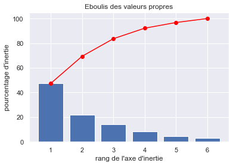

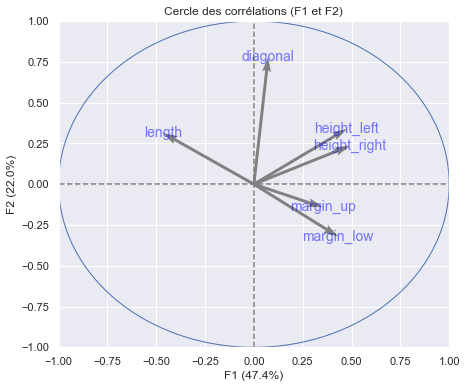

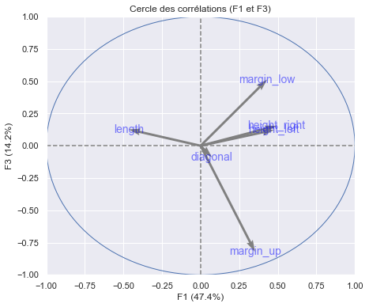

```python
import pandas as pd
import numpy as np
from sklearn import decomposition
from sklearn import preprocessing

# choix du nombre de composantes à calculer
n_comp = 6

# import de l'échantillon
data = billets[['diagonal', 'height_left', 'height_right', 'margin_low', 'margin_up','length']]

# selection des colonnes à prendre en compte dans l'ACP
data_pca = data[['diagonal', 'height_left', 'height_right', 'margin_low', 'margin_up','length']]

# préparation des données pour l'ACP
data_pca = data_pca.fillna(data_pca.mean()) # Il est fréquent de remplacer les valeurs inconnues par la moyenne de la variable
X = data_pca.values
names = data.index # ou data.index pour avoir les intitulés
features = data.columns

# Centrage et Réduction
std_scale = preprocessing.StandardScaler().fit(X)
X_scaled = std_scale.transform(X)#ici

# Calcul des composantes principales
pca = decomposition.PCA(n_components=n_comp)
pca.fit(X_scaled)

# Eboulis des valeurs propres
plt.savefig("p6_figures/ebouli_valeurs_propores.png")
display_scree_plot(pca)

# Cercle des corrélations
pcs = pca.components_
display_circles(pcs, n_comp, pca, [(0,1),(0,2)], labels = np.array(features))

plt.savefig("p6_figures/cercle_des_corelation.png")

plt.show()
```

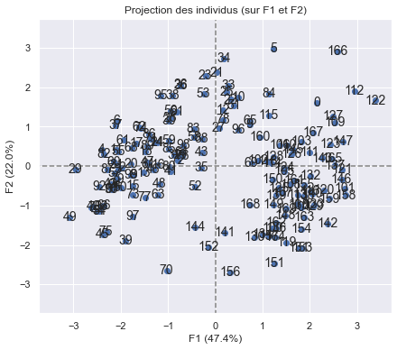

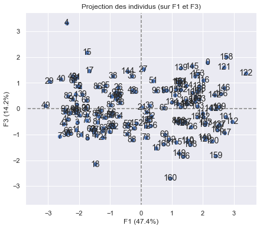

```python
# Projection des individus

X_projected = pca.transform(X_scaled)
#display_factorial_planes(X_projected, n_comp, pca, [(0,1),(2,3),(4,5)], labels = np.array(names))
display_factorial_planes(X_projected, n_comp, pca, [(0,1),(0,2)], labels = np.array(names))
plt.savefig('p6_figures/pca_projection.jpg')
plt.show()
```

```python
vsQuali=billets.is_genuine
```

```python
#Nous représentons les individus dans le plan factoriel, coloriées selon la modalité associée de la variable illustrative
#modalités de la variable qualitative

modalites = np.unique(vsQuali)
print(modalites)
```

```
[False  True]
```

```python
vsQuali
```

```
0       True
1       True
2       True
3       True
4       True
       ...
165    False
166    False
167    False
168    False
169    False
Name: is_genuine, Length: 170, dtype: bool
```

```python
x=pd.DataFrame(X)
```

```python
#liste des couleurs
couleurs = ['r','g','b']
#faire un graphique en coloriant les points
fig, axes = plt.subplots(figsize=(12,12))
axes.set_xlim(-3,3)
axes.set_ylim(-6,6)
#pour chaque modalité de la var. illustrative
for c in range(len(modalites)):
 #numéro des individus concernés
 numero = np.where(vsQuali == modalites[c])
 #les passer en revue pour affichage
for i in numero[0]:
    plt.annotate(x.index[i],(X[i,0],X[i,1]),color=couleurs[c])

#ajouter les axes
plt.plot([-6,6],[0,0],color='silver',linestyle='-',linewidth=1)
plt.plot([0,0],[-6,6],color='silver',linestyle='-',linewidth=1)
#affichage
plt.show()
```

[figure not shown]

```python
X_scaled
```

```
array([[-0.42834385,  2.6694537 ,  3.09656321, -0.13159013, -1.18987367,
         0.28163308],
       [-0.88755932, -1.09769709, -0.69125444, -0.86012554, -1.27473985,
         0.78069736],
       [-0.36274164, -1.03042654, -0.50943919, -0.30301023, -1.23230676,
         1.37740465],
       ...,
       [ 1.73652911,  0.68497248,  0.52084721,  0.38267015,  0.67718214,
        -2.05094997],
       [-0.39554274, -0.32408577, -0.1458087 ,  0.16839504,  1.61071005,
        -0.75989238],
       [ 0.06367273, -0.22317994,  0.06630909,  1.45404575,  0.38015054,
        -1.74717171]])
```

# Mission 2

Appliquez un algorithme de classification, puis analysez le résultat obtenu.

## valeurs observées

```python
billets = billets.fillna(billets.mean())
```

```python
billets
```

|  | is_genuine | diagonal | height_left | height_right | margin_low | margin_up | length | ind |
| --- | --- | --- | --- | --- | --- | --- | --- | --- |
| 0 | True | 171.81 | 104.86 | 104.95 | 4.52 | 2.89 | 112.83 | 1 |
| 1 | True | 171.67 | 103.74 | 103.70 | 4.01 | 2.87 | 113.29 | 2 |
| 2 | True | 171.83 | 103.76 | 103.76 | 4.40 | 2.88 | 113.84 | 3 |
| 3 | True | 171.80 | 103.78 | 103.65 | 3.73 | 3.12 | 113.63 | 4 |
| 4 | True | 172.05 | 103.70 | 103.75 | 5.04 | 2.27 | 113.55 | 5 |
| ... | ... | ... | ... | ... | ... | ... | ... | ... |
| 165 | False | 172.11 | 104.23 | 104.45 | 5.24 | 3.58 | 111.78 | 166 |
| 166 | False | 173.01 | 104.59 | 104.31 | 5.04 | 3.05 | 110.91 | 167 |
| 167 | False | 172.47 | 104.27 | 104.10 | 4.88 | 3.33 | 110.68 | 168 |
| 168 | False | 171.82 | 103.97 | 103.88 | 4.73 | 3.55 | 111.87 | 169 |
| 169 | False | 171.96 | 104.00 | 103.95 | 5.63 | 3.26 | 110.96 | 170 |

170 rows × 8 columns

```python
billet_ind=billets.set_index('is_genuine')
```

```python
billet_ind
```

| is_genuine | diagonal | height_left | height_right | margin_low | margin_up | length | ind |
| --- | --- | --- | --- | --- | --- | --- | --- |
| True | 171.81 | 104.86 | 104.95 | 4.52 | 2.89 | 112.83 | 1 |
| True | 171.67 | 103.74 | 103.70 | 4.01 | 2.87 | 113.29 | 2 |
| True | 171.83 | 103.76 | 103.76 | 4.40 | 2.88 | 113.84 | 3 |
| True | 171.80 | 103.78 | 103.65 | 3.73 | 3.12 | 113.63 | 4 |
| True | 172.05 | 103.70 | 103.75 | 5.04 | 2.27 | 113.55 | 5 |
| ... | ... | ... | ... | ... | ... | ... | ... |
| False | 172.11 | 104.23 | 104.45 | 5.24 | 3.58 | 111.78 | 166 |
| False | 173.01 | 104.59 | 104.31 | 5.04 | 3.05 | 110.91 | 167 |
| False | 172.47 | 104.27 | 104.10 | 4.88 | 3.33 | 110.68 | 168 |
| False | 171.82 | 103.97 | 103.88 | 4.73 | 3.55 | 111.87 | 169 |
| False | 171.96 | 104.00 | 103.95 | 5.63 | 3.26 | 110.96 | 170 |

170 rows × 7 columns

```python
import pandas as pd
import numpy as np
import matplotlib.pyplot as plt
from sklearn.cluster import KMeans
from sklearn import decomposition

# Nombre de clusters souhaités
n_clust = 2

# import de l'échantillon
data =billet_ind[['diagonal', 'height_left', 'height_right', 'margin_low', 'margin_up','length']]

# préparation des données pour le clustering
X = data.values
names = data.index
# Réduire n'est ici pas nécessaire car les variables sont exprimées dans la même unité
X_scaled = preprocessing.StandardScaler().fit_transform(X)

# Clustering par K-means
km = KMeans(n_clusters=n_clust)
km.fit(X)

# Récupération des clusters attribués à chaque individu
clusters = km.labels_

# Affichage du clustering par projection des individus sur le premier plan factoriel
#pca = decomposition.PCA(n_components=3).fit(X)
#X_projected = pca.transform(X)
#plt.scatter(X_projected[:, 0], X_projected[:, 1], c=clusters.astype(np.float), cmap = 'jet', alpha=.2)
#plt.title("Projection des {} individus sur le 1e plan factoriel".format(X_projected.shape[0]))
#plt.show(block=False)
```

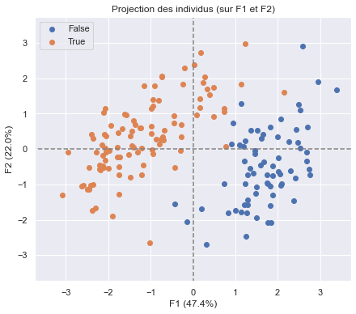

```python
display_factorial_planes(X_projected, n_comp, pca, [(0,1)],  illustrative_var= np.array(names))
plt.savefig("p6_figures/projection_valeurs_observées.png")
plt.show()
```

## VAleurs prédites

```python
billets
```

|  | is_genuine | diagonal | height_left | height_right | margin_low | margin_up | length | ind |
| --- | --- | --- | --- | --- | --- | --- | --- | --- |
| 0 | True | 171.81 | 104.86 | 104.95 | 4.52 | 2.89 | 112.83 | 1 |
| 1 | True | 171.67 | 103.74 | 103.70 | 4.01 | 2.87 | 113.29 | 2 |
| 2 | True | 171.83 | 103.76 | 103.76 | 4.40 | 2.88 | 113.84 | 3 |
| 3 | True | 171.80 | 103.78 | 103.65 | 3.73 | 3.12 | 113.63 | 4 |
| 4 | True | 172.05 | 103.70 | 103.75 | 5.04 | 2.27 | 113.55 | 5 |
| ... | ... | ... | ... | ... | ... | ... | ... | ... |
| 165 | False | 172.11 | 104.23 | 104.45 | 5.24 | 3.58 | 111.78 | 166 |
| 166 | False | 173.01 | 104.59 | 104.31 | 5.04 | 3.05 | 110.91 | 167 |
| 167 | False | 172.47 | 104.27 | 104.10 | 4.88 | 3.33 | 110.68 | 168 |
| 168 | False | 171.82 | 103.97 | 103.88 | 4.73 | 3.55 | 111.87 | 169 |
| 169 | False | 171.96 | 104.00 | 103.95 | 5.63 | 3.26 | 110.96 | 170 |

170 rows × 8 columns

```python
billets = billets.fillna(billets.mean())
```

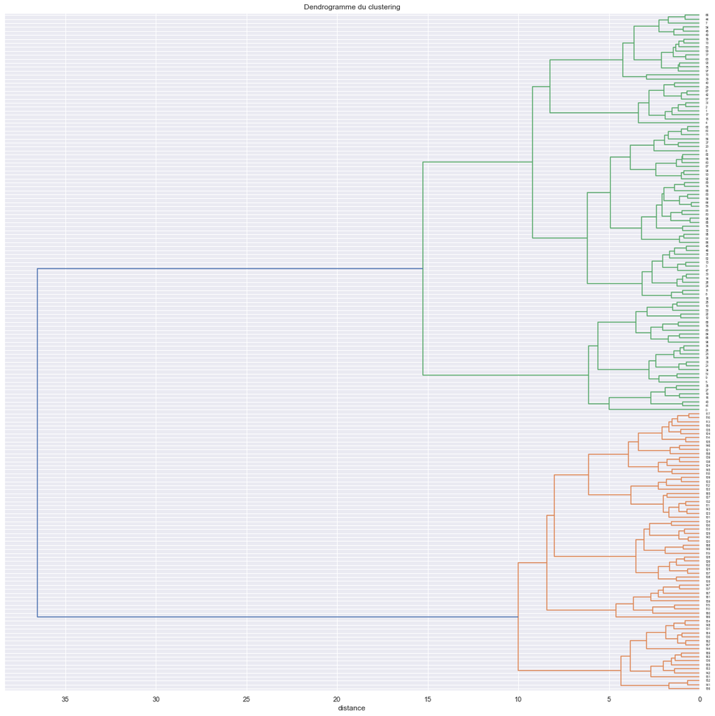

```python
import pandas as pd
#from functions import plot_dendrogram
from scipy.cluster.hierarchy import linkage, fcluster
from sklearn import preprocessing



# préparation des données pour le clustering
X = billets.values
names = billets.index

# Centrage et Réduction
std_scale = preprocessing.StandardScaler().fit(X)
X_scaled = std_scale.transform(X)

# Clustering hiérarchique
Z = linkage(X_scaled, 'ward')

# Affichage du dendrogramme

plt.figure(figsize=(20,20))
dendrogram(Z,
        labels = names,
        orientation = "left")
plt.title('Dendrogramme du clustering')
plt.xlabel('distance')


plt.savefig('p6_figures/dendogram.jpg')
plt.show()
```

avec le k means

```python
import pandas as pd
import numpy as np
import matplotlib.pyplot as plt
from sklearn.cluster import KMeans
from sklearn import decomposition

# Nombre de clusters souhaités
n_clust = 3

# import de l'échantillon
data =billets[['diagonal', 'height_left', 'height_right', 'margin_low', 'margin_up','length']]

# préparation des données pour le clustering
X = data.values

# Réduire n'est ici pas nécessaire car les variables sont exprimées dans la même unité
X_scaled = preprocessing.StandardScaler().fit_transform(X)

# Clustering par K-means
km = KMeans(n_clusters=n_clust)
km.fit(X)

# Récupération des clusters attribués à chaque individu
clusters = km.labels_

# Affichage du clustering par projection des individus sur le premier plan factoriel
#pca = decomposition.PCA(n_components=3).fit(X)
#X_projected = pca.transform(X)
#plt.scatter(X_projected[:, 0], X_projected[:, 1], c=clusters.astype(np.float), cmap = 'jet', alpha=.2)
#plt.title("Projection des {} individus sur le 1e plan factoriel".format(X_projected.shape[0]))
#plt.show(block=False)
```

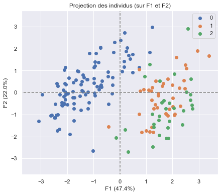

```python
display_factorial_planes(X_projected, n_comp, pca, [(0,1)],  illustrative_var= np.array(clusters))

plt.show()
```

```python
billets
```

|  | is_genuine | diagonal | height_left | height_right | margin_low | margin_up | length | ind |
| --- | --- | --- | --- | --- | --- | --- | --- | --- |
| 0 | True | 171.81 | 104.86 | 104.95 | 4.52 | 2.89 | 112.83 | 1 |
| 1 | True | 171.67 | 103.74 | 103.70 | 4.01 | 2.87 | 113.29 | 2 |
| 2 | True | 171.83 | 103.76 | 103.76 | 4.40 | 2.88 | 113.84 | 3 |
| 3 | True | 171.80 | 103.78 | 103.65 | 3.73 | 3.12 | 113.63 | 4 |
| 4 | True | 172.05 | 103.70 | 103.75 | 5.04 | 2.27 | 113.55 | 5 |
| ... | ... | ... | ... | ... | ... | ... | ... | ... |
| 165 | False | 172.11 | 104.23 | 104.45 | 5.24 | 3.58 | 111.78 | 166 |
| 166 | False | 173.01 | 104.59 | 104.31 | 5.04 | 3.05 | 110.91 | 167 |
| 167 | False | 172.47 | 104.27 | 104.10 | 4.88 | 3.33 | 110.68 | 168 |
| 168 | False | 171.82 | 103.97 | 103.88 | 4.73 | 3.55 | 111.87 | 169 |
| 169 | False | 171.96 | 104.00 | 103.95 | 5.63 | 3.26 | 110.96 | 170 |

170 rows × 8 columns

```python
data_class_K3 = pd.DataFrame({'ind' : billets.index.tolist(),
                             'clusters' : clusters})
```

```python
data_class_K3=data_class_K3.sort_values(['clusters','ind'])
```

```python
data_class_K3
```

|  | ind | clusters |
| --- | --- | --- |
| 1 | 1 | 0 |
| 2 | 2 | 0 |
| 3 | 3 | 0 |
| 4 | 4 | 0 |
| 5 | 5 | 0 |
| ... | ... | ... |
| 162 | 162 | 2 |
| 163 | 163 | 2 |
| 166 | 166 | 2 |
| 167 | 167 | 2 |
| 169 | 169 | 2 |

170 rows × 2 columns

```python
data_mrg_K3 = pd.merge(billets, data_class_K3, on='ind')
```

```python
data_mrg=data_mrg_K3[['diagonal', 'height_left','height_right','margin_low','margin_up','length','clusters']]
```

```python
illustrative_var_K3 = data_mrg['clusters']
```

```python
illustrative_var_K3
```

```
0      0
1      0
2      0
3      0
4      0
      ..
164    1
165    2
166    2
167    1
168    2
Name: clusters, Length: 169, dtype: int32
```

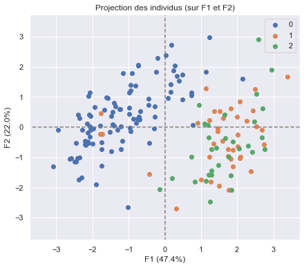

```python
X_projected = pca.transform(X_scaled)
display_factorial_planes(X_projected, n_comp, pca, [(0,1)], illustrative_var=illustrative_var_K3)
```

le clustering en 3 catégories n'est pas adapté pour ce model en remarque deux groupes qui se chevauchent

## clustering avec K-means

```python
import pandas as pd
import numpy as np
import matplotlib.pyplot as plt
from sklearn.cluster import KMeans
from sklearn import decomposition

# Nombre de clusters souhaités
n_clust = 2

# import de l'échantillon
data =billets[['diagonal', 'height_left', 'height_right', 'margin_low', 'margin_up','length']]

# préparation des données pour le clustering
X = data.values

# Réduire n'est ici pas nécessaire car les variables sont exprimées dans la même unité
X_scaled = preprocessing.StandardScaler().fit_transform(X)

# Clustering par K-means
km = KMeans(n_clusters=n_clust)
km.fit(X)

# Récupération des clusters attribués à chaque individu
clusters = km.labels_

# Affichage du clustering par projection des individus sur le premier plan factoriel
#pca = decomposition.PCA(n_components=3).fit(X)
#X_projected = pca.transform(X)
#plt.scatter(X_projected[:, 0], X_projected[:, 1], c=clusters.astype(np.float), cmap = 'jet', alpha=.2)
#plt.title("Projection des {} individus sur le 1e plan factoriel".format(X_projected.shape[0]))
#plt.show(block=False)
```

```python
 #display_factorial_planes(X_projected, n_comp, pca, [(0,1)],  illustrative_var= np.array(clusters))

#plt.show()
```

```python
data_class_K2 = pd.DataFrame({'ind' : billets.index.tolist(),
                             'clusters' : clusters})
```

```python
data_class_K2=data_class_K2.sort_values(['clusters','ind'])
```

```python
data_mrg_K2 = pd.merge(billets, data_class_K2, on='ind')
```

```python
data_mrg_K2
```

|  | is_genuine | diagonal | height_left | height_right | margin_low | margin_up | length | ind | clusters |
| --- | --- | --- | --- | --- | --- | --- | --- | --- | --- |
| 0 | True | 171.81 | 104.86 | 104.95 | 4.52 | 2.89 | 112.83 | 1 | 0 |
| 1 | True | 171.67 | 103.74 | 103.70 | 4.01 | 2.87 | 113.29 | 2 | 0 |
| 2 | True | 171.83 | 103.76 | 103.76 | 4.40 | 2.88 | 113.84 | 3 | 0 |
| 3 | True | 171.80 | 103.78 | 103.65 | 3.73 | 3.12 | 113.63 | 4 | 0 |
| 4 | True | 172.05 | 103.70 | 103.75 | 5.04 | 2.27 | 113.55 | 5 | 0 |
| ... | ... | ... | ... | ... | ... | ... | ... | ... | ... |
| 164 | False | 171.43 | 104.26 | 103.97 | 5.73 | 3.14 | 111.82 | 165 | 1 |
| 165 | False | 172.11 | 104.23 | 104.45 | 5.24 | 3.58 | 111.78 | 166 | 1 |
| 166 | False | 173.01 | 104.59 | 104.31 | 5.04 | 3.05 | 110.91 | 167 | 1 |
| 167 | False | 172.47 | 104.27 | 104.10 | 4.88 | 3.33 | 110.68 | 168 | 1 |
| 168 | False | 171.82 | 103.97 | 103.88 | 4.73 | 3.55 | 111.87 | 169 | 1 |

169 rows × 9 columns

```python
data_mrg=data_mrg_K2[['diagonal', 'height_left','height_right','margin_low','margin_up','length','clusters']]
```

```python
illustrative_var_K2 = data_mrg['clusters']
```

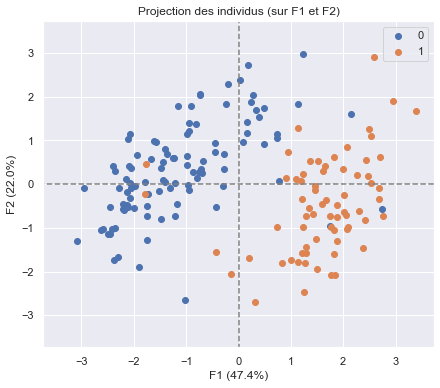

```python
X_projected = pca.transform(X_scaled)
plt.savefig("p6_figures/projection_valeurs_predites.png")
display_factorial_planes(X_projected, n_comp, pca, [(0,1)], illustrative_var=illustrative_var_K2)
```

```python
pd.crosstab(data_mrg_K2['is_genuine'],data_mrg_K2.clusters)
```

| clusters is_genuine | 0 | 1 |
| --- | --- | --- |
| False | 2 | 67 |
| True | 98 | 2 |

```python
print('la probabilité pour que la prediction soit vraie est de:',(98+67)*100/(98+67+2+2),'%')
```

```
la probabilité pour que la prediction soit vraie est de: 97.63313609467455 %
```

# Modélisez les données à l'aide d'une régression logistique.

```python
import seaborn as sns
import matplotlib.pyplot as plt
import statsmodels.formula.api as smf
import statsmodels.api as sm
from sklearn.linear_model import LogisticRegression
```

## Visualisez le nuage de points

```python
billets.columns
```

```
Index(['is_genuine', 'diagonal', 'height_left', 'height_right', 'margin_low',
       'margin_up', 'length', 'ind'],
      dtype='object')
```

```python
billets_log=billets.replace([True,False],[1,0])
```

```python
billets_log
```

|  | is_genuine | diagonal | height_left | height_right | margin_low | margin_up | length | ind |
| --- | --- | --- | --- | --- | --- | --- | --- | --- |
| 0 | 1 | 171.81 | 104.86 | 104.95 | 4.52 | 2.89 | 112.83 | 1 |
| 1 | 1 | 171.67 | 103.74 | 103.70 | 4.01 | 2.87 | 113.29 | 2 |
| 2 | 1 | 171.83 | 103.76 | 103.76 | 4.40 | 2.88 | 113.84 | 3 |
| 3 | 1 | 171.80 | 103.78 | 103.65 | 3.73 | 3.12 | 113.63 | 4 |
| 4 | 1 | 172.05 | 103.70 | 103.75 | 5.04 | 2.27 | 113.55 | 5 |
| ... | ... | ... | ... | ... | ... | ... | ... | ... |
| 165 | 0 | 172.11 | 104.23 | 104.45 | 5.24 | 3.58 | 111.78 | 166 |
| 166 | 0 | 173.01 | 104.59 | 104.31 | 5.04 | 3.05 | 110.91 | 167 |
| 167 | 0 | 172.47 | 104.27 | 104.10 | 4.88 | 3.33 | 110.68 | 168 |
| 168 | 0 | 171.82 | 103.97 | 103.88 | 4.73 | 3.55 | 111.87 | 169 |
| 169 | 0 | 171.96 | 104.00 | 103.95 | 5.63 | 3.26 | 110.96 | 170 |

170 rows × 8 columns

```python
billets_log.isna().sum()
```

```
is_genuine      0
diagonal        0
height_left     0
height_right    0
margin_low      0
margin_up       0
length          0
ind             0
dtype: int64
```

## Visualisez le nuage de points

### la variable "diagonal"

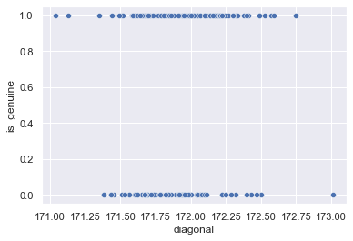

```python
sns.set()

ax = sns.scatterplot(x="diagonal", y="is_genuine", data=billets_log)
```

## la variable "height_left"

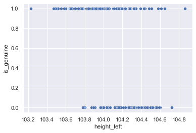

```python
sns.set()

ax = sns.scatterplot(x="height_left", y="is_genuine", data=billets_log)
```

## variable height_right

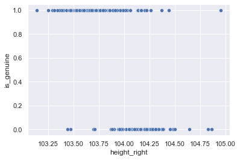

```python
sns.set()

ax = sns.scatterplot(x="height_right", y="is_genuine", data=billets_log)
```

## variable margin_low

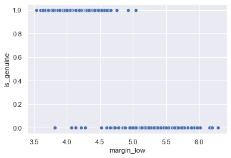

```python
sns.set()

ax = sns.scatterplot(x="margin_low", y="is_genuine", data=billets_log)
```

## variable margin_up

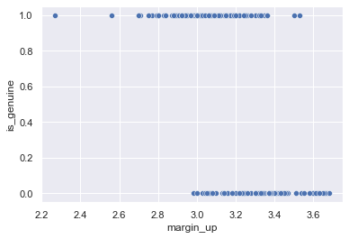

```python
sns.set()

ax = sns.scatterplot(x="margin_up", y="is_genuine", data=billets_log)
```

## variable length

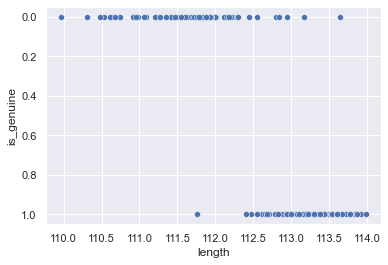

```python
sns.set()

ax = sns.scatterplot(x="length", y="is_genuine", data=billets_log)
```

# regresion logistique

```python
def check_money_proba(data, data_test):
    y = data['is_genuine']
    X = data.drop('is_genuine', axis = 1)
    model  = LogisticRegression()
    model.fit(X, y)
```

```python
import pandas as pd
import numpy as np
import statsmodels.api as sm
from sklearn.linear_model import LogisticRegression



billets_log["is_genuine"] = billets_log["is_genuine"].astype('category')

# on définit x et y
y = billets_log["is_genuine"]
# on ne prend que les colonnes quantitatives
x = billets_log.drop('is_genuine', axis = 1)
```

```python
# on ajoute une colonne pour la constante
x_stat = sm.add_constant(x)
# on ajuste le modèle
model = sm.Logit(y, x_stat)
result = model.fit(method='lbfgs',max_iterations=1000)
```

```python
result.summary()
```

Logit Regression Results

| Dep. Variable: | is_genuine | No. Observations: | 170 |
| --- | --- | --- | --- |
| Model: | Logit | Df Residuals: | 162 |
| Method: | MLE | Df Model: | 7 |
| Date: | Thu, 14 Apr 2022 | Pseudo R-squ.: | 1.000 |
| Time: | 16:33:50 | Log-Likelihood: | -4.8025e-05 |
| converged: | True | LL-Null: | -115.17 |
| Covariance Type: | nonrobust | LLR p-value: | 4.186e-46 |

|  | coef | std err | z | P>\|z\| | [0.025 | 0.975] |
| --- | --- | --- | --- | --- | --- | --- |
| const | 0.0194 | nan | nan | nan | nan | nan |
| diagonal | 3.8111 | nan | nan | nan | nan | nan |
| height_left | 1.7002 | nan | nan | nan | nan | nan |
| height_right | 0.7913 | nan | nan | nan | nan | nan |
| margin_low | -1.5242 | nan | nan | nan | nan | nan |
| margin_up | -0.6550 | nan | nan | nan | nan | nan |
| length | 4.3696 | nan | nan | nan | nan | nan |
| ind | -13.8875 | nan | nan | nan | nan | nan |

Complete Separation: The results show that there iscomplete separation.  
In this case the Maximum Likelihood Estimator does not exist and the parameters  
are not identified.

ce probleme c'est produit car il y'a une variable trés corelée aux autres variables j'ai pris la decision d'utiliser la heat map pour le test de coorelation

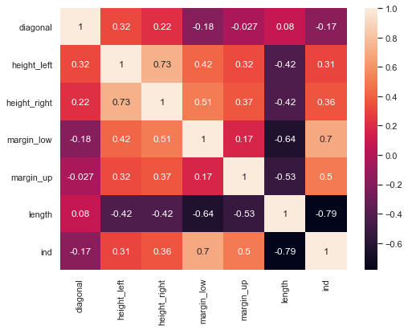

```python
import pandas as pd
import seaborn as sns
import matplotlib.pyplot as plt

#employees_df = billets_logpd.DataFrame({'diagonal','height_left','height_right','margin_low','margin_up','length'


corr_df = billets_log.corr(method='pearson')

plt.figure(figsize=(8, 6))
sns.heatmap(corr_df, annot=True)
plt.savefig("p6_figures/heat_map.png")
plt.show()
```